# 1) Importing the Libraries

```python
# %pip install matplotlib==3.4.1 --quiet
# %pip install spacy --quiet
# %pip install transformers --quiet
# %pip install sentence_transformers --quiet
# %pip install nltk --quiet
# %pip install pandas --quiet
# %pip install seaborn --quiet
# %pip install spacy --quiet
# %pip install openpyxl --quiet
```

```python
import nltk
from os import path
import numpy as np
import pandas as pd
from string import *
import seaborn as sns
import matplotlib.pyplot as plt
from sklearn.cluster import KMeans
from matplotlib import pyplot as plt
from nltk.stem import WordNetLemmatizer
from sklearn.metrics.pairwise import cosine_similarity
# from sklearn.metrics.cluster import adjusted_rand_score, silhouette_score
nltk.download('stopwords')
nltk.download('wordnet')
stop_words = set(nltk.corpus.stopwords.words('english'))
lemmatizer = WordNetLemmatizer()
from sklearn.decomposition import PCA
from transformers import AutoTokenizer, AutoModel, pipeline
import torch
import csv
from bertopic import BERTopic
import re
```

# 2) Reading the relevant xlsx file

```python
input = pd.read_excel("input.xlsx")
input
```

|  | corpus |
| --- | --- |
| 0 | Gap-Based Education, Changing Competence, and ... |
| 1 | Science Education in the Preclinical Curriculum |
| 2 | SPECIAL TUBERCULOSIS EXAMINATIONS IN THE MILIT... |
| 3 | Adaptive tracking control design of constraine... |
| 4 | Archives of Internal Medicine Reader's Choice:... |
| ... | ... |
| 967 | MILITARY SURGERY OF THE FUTURE. |
| 968 | Body Mass Index and Asthma in the Military Pop... |
| 969 | The fallacy of amelioration: Thinking through ... |
| 970 | LARYNGEAL NEUROSIS INCIDENT TO MILITARY SERVICE |
| 971 | Mobile robot localization based on eigenspace ... |

972 rows × 1 columns

# 3) Data Preparation

- Data preprocessing: Was ist nötig im Kontext von BERT und Transformer models?
- NLP spezifisch
  - stopwords entfernen: Nicht unbedingt notwendig. BERT-Modelle sind in der Lage, den Kontext von Wörtern zu verstehen, sodass Stopwörter oft nicht explizit entfernt werden müssen. In einigen Fällen kann es jedoch hilfreich sein, um den Text zu vereinfachen.
  - Groß- u Kleinschreibung ignorieren: Nicht notwendig. Die meisten BERT-Modelle verwenden eine eigene Tokenisierung, die die Groß- und Kleinschreibung berücksichtigt. Modelle wie bert-base-uncased sind bereits auf Kleinschreibung trainiert.
  - Sonderzeichen ignorieren: Nicht notwendig. BERT-Tokenizer behandeln Sonderzeichen explizit und behalten sie bei, um den Kontext nicht zu verlieren.
  - Tokenisierung: Notwendig. Die BERT-Tokenisierung erfolgt durch spezialisierte Tokenizer (wie WordPiece oder SentencePiece), die den Text in Subwort-Einheiten aufteilen. Dies ist ein integraler Bestandteil der Verarbeitung mit BERT.
  - Lemmatisierung: nicht nötig wegen großem Trainingsdatensatz (Nicht notwendig. BERT verarbeitet Wörter in ihrem Kontext und die Subwort-Tokenisierung macht eine explizite Lemmatisierung überflüssig.)
- Generell
  - NAs und Duplikate entfernen

```python
input = input.dropna().drop_duplicates(subset=['corpus'])
```

```python
input['abstract_list'] =  input['corpus'].apply(lambda x : x.split(' '))
input['abstract_list_len'] =  input['abstract_list'].apply(lambda x : len(x))

input.sort_values(by = "abstract_list_len")
```

|  | corpus | abstract_list | abstract_list_len |
| --- | --- | --- | --- |
| 691 | Military Psychiatry | [Military, Psychiatry] | 2 |
| 232 | MILITARY MEDICINE | [MILITARY, MEDICINE] | 2 |
| 351 | MEDICO-MILITARY RANK. | [MEDICO-MILITARY, RANK.] | 2 |
| 712 | MEDICO-MILITARY STATISTICS. | [MEDICO-MILITARY, STATISTICS.] | 2 |
| 884 | DERMATOLOGIC EDUCATION | [DERMATOLOGIC, EDUCATION] | 2 |
| ... | ... | ... | ... |
| 397 | Muscle fatigue mechanisms in exercise and trai... | [Muscle, fatigue, mechanisms, in, exercise, an... | 35 |
| 412 | A Manual of Instruction in the Principles of P... | [A, Manual, of, Instruction, in, the, Principl... | 36 |
| 788 | Case Conferences - Safeguarding Children/Cynad... | [Case, Conferences, -, Safeguarding, Children/... | 37 |
| 213 | NATIONAL ASSOCIATION OF MILITARY SURGEONS OF T... | [NATIONAL, ASSOCIATION, OF, MILITARY, SURGEONS... | 37 |
| 7 | Injuries and sport. A general guide to the pra... | [Injuries, and, sport., A, general, guide, to,... | 47 |

848 rows × 3 columns

- Maximale Länge des Korpus: 47 Wörter -> wir brauchen nichts zu kürzen wie im Notebook
- wir erstellen eine Spalte `corpus_clean`, die den Text bereinigt (Sonderzeichen, kleinschriebung, lemmata). Wir könnten darauf ebenfalls clustern, allerdings sollte der unbehandelte Corpus bereits geeignete Ergebnisse bringen, da BERT 1. case-insensitive ist und 2. auf große Trainingsdatensätze trainiert ist, die keine Lemmatisierung & Bereinigung benötigen (siehe Punkte oben). Ich erstelle sie hier nur, falls sie später zur Kontrolle benötigt wird.

```python
def remove_stop_lemmatize(text):
    text = text.replace('-',' ')
    text = re.sub (r'([^a-zA-Z ]+?)', '', text)
    text = text.split(' ')
    return ' '.join(lemmatizer.lemmatize(word.lower()) for word in text if word.lower() not in stop_words)

input["corpus_clean"] = input["corpus"].apply(remove_stop_lemmatize)
input
```

|  | corpus | abstract_list | abstract_list_len | corpus_clean |
| --- | --- | --- | --- | --- |
| 0 | Gap-Based Education, Changing Competence, and ... | [Gap-Based, Education,, Changing, Competence,,... | 7 | gap based education changing competence dermat... |
| 1 | Science Education in the Preclinical Curriculum | [Science, Education, in, the, Preclinical, Cur... | 6 | science education preclinical curriculum |
| 2 | SPECIAL TUBERCULOSIS EXAMINATIONS IN THE MILIT... | [SPECIAL, TUBERCULOSIS, EXAMINATIONS, IN, THE,... | 7 | special tuberculosis examination military service |
| 3 | Adaptive tracking control design of constraine... | [Adaptive, tracking, control, design, of, cons... | 8 | adaptive tracking control design constrained r... |
| 4 | Archives of Internal Medicine Reader's Choice:... | [Archives, of, Internal, Medicine, Reader's, C... | 9 | archive internal medicine reader choice contin... |
| ... | ... | ... | ... | ... |
| 967 | MILITARY SURGERY OF THE FUTURE. | [MILITARY, SURGERY, OF, THE, FUTURE.] | 5 | military surgery future |
| 968 | Body Mass Index and Asthma in the Military Pop... | [Body, Mass, Index, and, Asthma, in, the, Mili... | 14 | body mass index asthma military population nor... |
| 969 | The fallacy of amelioration: Thinking through ... | [The, fallacy, of, amelioration:, Thinking, th... | 13 | fallacy amelioration thinking knowledge transl... |
| 970 | LARYNGEAL NEUROSIS INCIDENT TO MILITARY SERVICE | [LARYNGEAL, NEUROSIS, INCIDENT, TO, MILITARY, ... | 6 | laryngeal neurosis incident military service |
| 971 | Mobile robot localization based on eigenspace ... | [Mobile, robot, localization, based, on, eigen... | 7 | mobile robot localization based eigenspace ana... |

848 rows × 4 columns

# 4) EDA

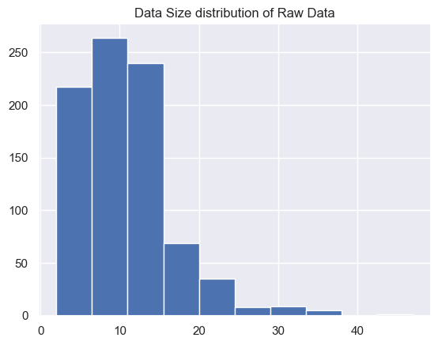

```python
plt.hist(input['abstract_list_len'])
plt.title('Data Size distribution of Raw Data')
```

- Da wir hier nichts gekürzt haben, dient der obige Plot nur zur Übersicht der Länge der Texte

# 5) Cosine SImilarity-

```python
def create_similarity_heatmap(corpus_embeddings):
    similarity_matrix = cosine_similarity(corpus_embeddings)
    sns.set(font_scale=1)
    f, ax = plt.subplots(figsize=(11, 9))
    c = sns.heatmap(similarity_matrix, square=True,  ax=ax)
    c.set(xlabel='Document ID', ylabel='Document ID')
    plt.show()
    fig = c.get_figure()
    fig.suptitle('TF-IDF Document Similarity Matrix', fontsize=25)
```

# 6) Clustering

## 6.a) Elbow Plot

```python
def plot_elbow_method(embedding):

    Sum_of_squared_distances = []
    K = range(1,15)
    for k in K:
        km = KMeans(n_clusters=k)
        km = km.fit(embedding)
        Sum_of_squared_distances.append(km.inertia_)
    plt.plot(K, Sum_of_squared_distances, 'bx-')
    plt.xlabel('k')
    plt.ylabel('Sum_of_squared_distances')
    plt.title('Elbow Method For Optimal k')
    plt.show()
```

## 6.b) PCA and Kmeans

```python
def get_cluster_kmeans(vectorize, num_clusters, r_state=100):
    km = KMeans(n_clusters = num_clusters, random_state=r_state )
    km.fit(vectorize)
    cluster_list = km.labels_.tolist()
    return cluster_list

def pca_reduction(similarity_matrix, n_components):
    one_min_sim = 1 - similarity_matrix
    pca = PCA(n_components)
    pos = pca.fit_transform(one_min_sim)
    x_pos, y_pos = pos[:, 0], pos[:, 1]
    return (x_pos, y_pos)
```

## 6.c) Plotting Scatter plot -2D

```python
def plot_graph(clusters, umap_data):
    result = pd.DataFrame(umap_data, columns=['x', 'y'])
    result['labels'] = clusters
    plt.figure(figsize=(10,10))
    sns.scatterplot(
        x="x", y="y",
        hue="labels",
        palette='Spectral',
        data=result,
        legend="full"
    )
```

# 7) Choosing the right model

sentence-transformers/bert-base-nli-mean-tokens:

`⚠️ This model is deprecated. Please don't use it as it produces sentence embeddings of low quality. You can find recommended sentence embedding models here: SBERT.net - Pretrained Models`

- Daher werden wir eines der kleineren "Original Models" aus `https://sbert.net/docs/sentence_transformer/pretrained_models.html` nehmen, welches geeignet scheint (general use oder spezifisch für unsere Inhalte)
- sollten wir mehr Deutsche und auch anderssprachige Dokumente haben, sollten wir zu einem Mulitlingual model greifen. Hier sollte die dissimilarity zu Englischen Dokumenten bereits dafür sorgen, dass sie halbwegs geeignet geclustert werden.

## 7.a) Initiating the model

```python
#Mean Pooling - Take attention mask into account for correct averaging
def mean_pooling(model_output, attention_mask):
    token_embeddings = model_output[0] #First element of model_output contains all token embeddings
    input_mask_expanded = attention_mask.unsqueeze(-1).expand(token_embeddings.size()).float()
    sum_embeddings = torch.sum(token_embeddings * input_mask_expanded, 1)
    sum_mask = torch.clamp(input_mask_expanded.sum(1), min=1e-9)
    return sum_embeddings / sum_mask


model_author = "nreimers"
model_name = "MiniLM-L6-H384-uncased"

#Load AutoModel from huggingface model repository
tokenizer = AutoTokenizer.from_pretrained(model_author + "/" + model_name)
model = AutoModel.from_pretrained(model_author + "/" + model_name)

model_path = "data/"+model_name
```

- Hier prüfen wir ob s_bert embeddings schon gespeichert sind
- Ich habe den `model_path` dynamisch gemacht, um beliebige Modelle oben einzubinden.

```python
not path.exists(model_path)
```

```
False
```

```python
if not path.exists(model_path):
    with open(model_path, 'w', newline='') as file:
        writer = csv.writer(file)
        for sentence in input['corpus'].values:
            encoded_input = tokenizer(sentence, padding=True, truncation=True, max_length=450, return_tensors='pt')
            with torch.no_grad():
                model_output = model(**encoded_input)
            writer.writerow(mean_pooling(model_output, encoded_input['attention_mask']))
```

```python
mdl_res = pd.read_csv(model_path, header=None)
```

```python
mdl_res_list =[]
for i in mdl_res[0]:
    mdl_res_list.append([float(j) for j in i.replace('\n','').replace('tensor(','').replace(')','').replace('[','').replace(']','').split(',')])
```

```python
sentence_embeddings_df = pd.DataFrame(mdl_res_list)
```

```python
sentence_embeddings_df.head()
```

|  | 0 | 1 | 2 | 3 | 4 | 5 | 6 | 7 | 8 | 9 | ... | 374 | 375 | 376 | 377 | 378 | 379 | 380 | 381 | 382 | 383 |
| --- | --- | --- | --- | --- | --- | --- | --- | --- | --- | --- | --- | --- | --- | --- | --- | --- | --- | --- | --- | --- | --- |
| 0 | -0.51177 | 0.47391 | 0.066913 | 0.023980 | 0.076404 | -0.198280 | 0.75543 | 0.11836 | -0.061262 | 0.125430 | ... | 0.23266 | -0.057966 | 0.168150 | 0.149740 | 0.095360 | 0.158250 | 0.28441 | -0.135010 | 0.80728 | 0.076612 |
| 1 | -0.46342 | 0.26900 | -0.265760 | -0.018226 | -0.003763 | -0.170650 | 0.12256 | 0.31006 | -0.253300 | 0.063808 | ... | 0.14394 | 0.052169 | 0.081491 | 0.109860 | -0.121860 | -0.015120 | -0.12907 | 0.012415 | 0.46320 | -0.291900 |
| 2 | -0.43274 | 0.56580 | 0.039865 | 0.019363 | -0.322700 | 0.027712 | 0.29788 | 0.21835 | -0.081083 | -0.091251 | ... | 0.17807 | 0.131770 | 0.179370 | 0.068710 | 0.096693 | 0.251890 | -0.19185 | -0.085204 | 0.38330 | -0.025129 |
| 3 | -0.73125 | 0.43733 | -0.050462 | 0.053948 | -0.122230 | -0.043488 | 0.97980 | 0.14927 | -0.146560 | 0.118480 | ... | 0.21338 | 0.024326 | 0.025487 | -0.014118 | 0.282870 | 0.167180 | -0.10381 | -0.057314 | 0.34791 | -0.247120 |
| 4 | -0.46994 | 0.25845 | 0.222570 | 0.066008 | 0.031381 | 0.031879 | 0.50639 | 0.16011 | -0.038208 | -0.051461 | ... | 0.34913 | 0.021811 | 0.149090 | 0.115170 | -0.018452 | -0.019025 | 0.34777 | 0.027297 | 0.26623 | 0.169920 |

5 rows × 384 columns

```python
sentence_embeddings = np.array(sentence_embeddings_df)
```

## 7.c) Plotting the similarity Matrix

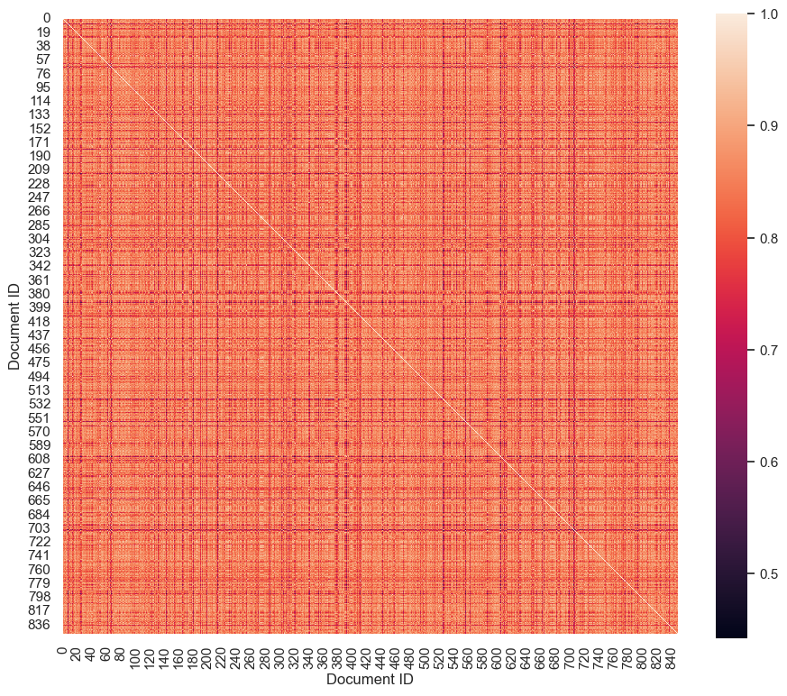

```python
# create_similarity_heatmap(sentence_embeddings[100:200,100:200])
create_similarity_heatmap(sentence_embeddings)
```

- Im obigen Plot sehen wir die errechnete Ähnlichkeit der Dokumente miteinander (1.0 = perfekte Ähnlichkeit)
- Die geplotteten Werte sind jeweils die "cosine similarity" (Ähnlichkeit der Embedding-Vektoren) der Dokumente untereinander, also wie ähnlich sich zwei der Headlines im Corpus sind.

### 7.c) KMeans Implementation

### Elbow Method to estimate # of clusters

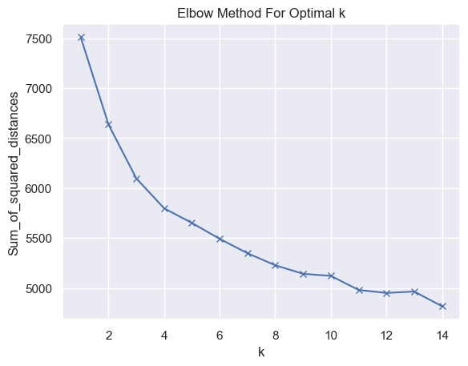

```python
plot_elbow_method(sentence_embeddings)
```

- Elbow plot plots the WCSS (within cluster sum of squares) = squared distance between each point and the centroid in a cluster
- as number of clusters increase, WCSS value decreases.
- K value corresponding to the point where the plot decreases more slowly is optimal -> we have diminishing win of WCSS with more clusters.
- The "elbow" is near 4, so we will chose 4 clusters

### PCA plot with KMEANS

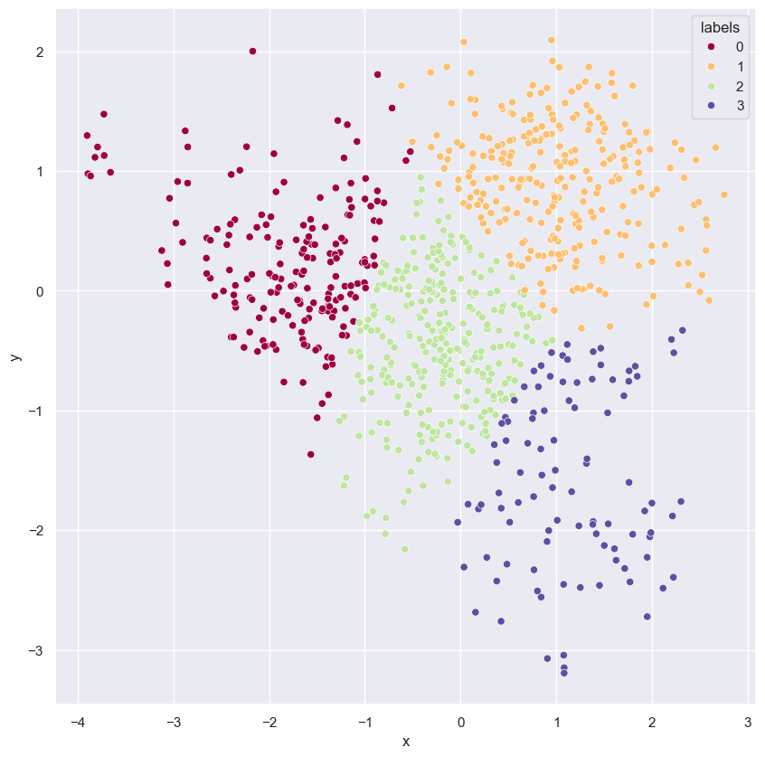

```python
number_of_clusters = 4
x_pos, y_pos = pca_reduction(sentence_embeddings, 2)
df = pd.DataFrame(x_pos,columns = ['x'])
df['y'] = y_pos
df.columns = ['x','y']
km_clusters_s_bert = get_cluster_kmeans(df, number_of_clusters)
plot_graph(km_clusters_s_bert, df)
```

# assign clusters and name topics

```python
input["cluster"] = km_clusters_s_bert
```

- kurze Übersicht über die Cluster, um manuell zu prüfen, ob man bereits Muster erkennen kann:

```python
input[input["cluster"] == 1]["corpus"]
```

```
0      Gap-Based Education, Changing Competence, and ...
3      Adaptive tracking control design of constraine...
12     Sex differences in causal attributions for suc...
13     An on-line robot planning strategy for target ...
17     An interactive control system for mobile robot...
                             ...
956    Active Disturbance Rejection Control Applied T...
958    A class of nonlinear PD-type controllers for r...
962    Identification for the robust control of robot...
965                On the controllability of a robot arm
971    Mobile robot localization based on eigenspace ...
Name: corpus, Length: 268, dtype: object
```

```python
input[input["cluster"] == 2]["corpus"]
```

```
1        Science Education in the Preclinical Curriculum
4      Archives of Internal Medicine Reader's Choice:...
6      Military Aeromedical Evacuations From Central ...
16        Reimagining Medical Education in the Age of AI
18     Textbooks of Military Medicine: Ophthalmic Car...
                             ...
960    It's Hardly Sport, but Parachuting Fire Fighte...
961    Skin Disease Among Men of Military Age in Sout...
968    Body Mass Index and Asthma in the Military Pop...
969    The fallacy of amelioration: Thinking through ...
970      LARYNGEAL NEUROSIS INCIDENT TO MILITARY SERVICE
Name: corpus, Length: 300, dtype: object
```

```python
input[input["cluster"] == 3]["corpus"]
```

```
7      Injuries and sport. A general guide to the pra...
14     IOC/IAKS AWARD "Beispielhafte Sport- und Freiz...
25     Decision and intelligence — robot technology v...
27     The Surgeon-Generals of the Army of the United...
65     Notes on Military Hygiene for Officers of the ...
                             ...
900    Error in Figure in: High Income, Employment, P...
913    Internships and Residencies in New York City, ...
919    “It's Only Sport”-The Symbolic Neutralization ...
963    Regarding the Pain of SpotMini: Or What a Robo...
966    IS THERE A RATIONALE FOR THE USE OF CREATINE E...
Name: corpus, Length: 97, dtype: object
```

# Try summarizing the topics

this doesn't work well yet.

```python
summarizer = pipeline('summarization', max_length = 32, min_length = 4)
```

```
No model was supplied, defaulted to sshleifer/distilbart-cnn-12-6 and revision a4f8f3e (https://huggingface.co/sshleifer/distilbart-cnn-12-6).
Using a pipeline without specifying a model name and revision in production is not recommended.
```

```python
for i in set(input["cluster"]):
    doc = input[input.cluster == 1]["corpus"].sample(50)
    to_summarize = " ".join(doc)
    print("cluster ", i, ":", summarizer(to_summarize))
```

```
cluster  0 : [{'summary_text': ' The Advent of Laparoscopic Pancreatic Surgery Using the Robot Motion of control of a multijoint robot based on a robust velocity controller .'}]
cluster  1 : [{'summary_text': ' IOC/IAKS Awards 2014: Preisgekrönte Sport- und Freizeitanlagen . Some remarks on convergence analysis of'}]
cluster  2 : [{'summary_text': ' Study of Cardiorespiratory and Stress Factors in Esophageal Surgery using Robot-Assisted Thoracoscopic or Open Thoracic'}]
cluster  3 : [{'summary_text': ' Robot assistant versus human or another robot assistant in patients undergoing laparoscopic cholecystectomy . Real-time line tracking based on web robot'}]
```

- We could use chatGPT API to get better keywords from these.
- That's what BERTopic can do, see https://medium.com/@pauloyc/topic-modelling-and-multiclass-text-classification-using-transformers-6fc3ee69c15d

# using BERTopic

*Alternativer Lösungsansatz*

- BERTopic nutzt, wie wir oben, Transformers, um Embeddings zu bekommen, und Clustert danach die Embeddings mit UMAP & HDBSCAN.
- Hier eine Beschreibung, die ich während meines Praktikums bei Yagora erstellt habe, als ich BERTopic nutzte:
- siehe https://maartengr.github.io/BERTopic/getting_started/quickstart/quickstart.html für eine Übersicht

# How BERTopic works:

The algorithm contains, roughly, 4 stages:

- **Extract document embeddings with Sentence Transformers** (https://github.com/UKPLab/sentence-transformers) or TF-IDF
  - Sentence transformers basically transform sentences into *sentence embeddings*: Sentences with similar meaning are closer in vector space. Pre-trained models are used which can be fine-tuned for various use-cases.
- **Cluster document embeddings to create groups of similar documents with UMAP** (https://umap-learn.readthedocs.io/en/latest/clustering.html) **and HDBSCAN** (https://hdbscan.readthedocs.io/en/latest/how_hdbscan_works.html)
  - These algorithms cluster the previously transformed sentences into clusters with similar meaning, resulting in *clusters of topics.*
  - UMAP is used to recude the dimensionality, then HCBSCAN (which suffers from the curse of dimensionality) is used to cluster similar documents.
- **Extract and reduce topics with c-TF-IDF** (https://github.com/MaartenGr/cTFIDF)
  - c-TF-IDF is a class-based TF-IDF procedure that can be used to generate features from textual documents based on the class they are in.
  - Typical applications of c-TF-IDF:
    - Informative Words per Class: Which words make a class stand-out compared to all others?
    - Class Reduction: Using c-TF-IDF to reduce the number of classes
    - Semi-supervised Modeling: Predicting the class of unseen documents using only cosine similarity and c-TF-IDF
- **Improve coherence of words with Maximal Marginal Relevance** (https://www.researchgate.net/publication/221614169_Creating_and_Evaluating_Multi-Document_Sentence_Extract_Summaries)
  - A text passage has high marginal relevance if it is both relevant to the query and useful for a summary, while having minimal similarity to previously selected passages.
  - This will further improve the representativity of a keyword for a topic

> MMR considers the similarity of keywords/keyphrases with the document, along with the similarity of already selected keywords and keyphrases. This results in a selection of keywords that maximize their within diversity with respect to the document.

```python
topic_model = BERTopic(embedding_model=model_author+"/"+model_name, verbose = True, calculate_probabilities = True)
```

```python
# topics, probs = topic_model.fit_transform(input["corpus"])
topics, probs = topic_model.fit_transform(input["corpus_clean"])
```

```
2024-06-05 17:22:18,729 - BERTopic - Embedding - Transforming documents to embeddings.
No sentence-transformers model found with name nreimers/MiniLM-L6-H384-uncased. Creating a new one with mean pooling.
2024-06-05 17:22:22,269 - BERTopic - Embedding - Completed ✓
2024-06-05 17:22:22,270 - BERTopic - Dimensionality - Fitting the dimensionality reduction algorithm
2024-06-05 17:22:25,168 - BERTopic - Dimensionality - Completed ✓
2024-06-05 17:22:25,169 - BERTopic - Cluster - Start clustering the reduced embeddings
2024-06-05 17:22:25,210 - BERTopic - Cluster - Completed ✓
2024-06-05 17:22:25,212 - BERTopic - Representation - Extracting topics from clusters using representation models.
2024-06-05 17:22:25,231 - BERTopic - Representation - Completed ✓
```

- We can get the topic information using this command:

```python
topic_model.get_topic_info()
```

|  | Topic | Count | Name | Representation | Representative_Docs |
| --- | --- | --- | --- | --- | --- |
| 0 | -1 | 1 | -1_perfectionism_school_community_participation | [perfectionism, school, community, participati... | [ model perfectionism school community base... |
| 1 | 0 | 732 | 0_robot_military_sport_education | [robot, military, sport, education, control, m... | [continuing medical education, medical sport, ... |
| 2 | 1 | 49 | 1_military_sport_education_service | [military, sport, education, service, surgeon,... | [problem military dermatology, universal milit... |
| 3 | 2 | 27 | 2_sport_technology_military_service | [sport, technology, military, service, bayes, ... | [checkmate role gender stereotype ultimate int... |
| 4 | 3 | 23 | 3_education_even_personnel_robot | [education, even, personnel, robot, motion, gr... | [nature incidence impact eye injury among u mi... |
| 5 | 4 | 16 | 4_sport_solar_order_human | [sport, solar, order, human, hormone, tropical... | [event report brain sport world solar challen... |

- We could reduce and/or summarize topics if we wanted to (see Documentation of BERTopic)
- We can also visualize the topics, similar to our 2d clustering above:

```python
topic_model.visualize_topics()
```

[output not shown]

explanation of axis:

- the algorithm takes the c_tf_idf: a matrix containing a value (importance score) for each word per topic. In the c_tf_idf, words with high values within topics are representational for the respective topic.
- Now we normalize these "importance" values using MinMaxScaler (scales features between a given range): These will be the values of X and Y later.
- If word x is important in topic 1, it will have a high score there. In other topics it might have a lower score. As we have many topics, we need to reduce the dimensionality here.
- This is done by embedding the matrix into 2d using UMAP: An algorithm that is often used for visualization by reducing data to 2-dimensions. Similar to t-SNE but faster. For details in UMAP: It takes the two nearest neighbors, using the hellinger distance for probabilities.
- Now we will have similar topics near each other: Topics where words are similar in importance are closer to each other.
- Wir können auch auf n-gram-representations gehen (mehr als 1 wort-Tokens)

```python
topic_model.update_topics(input["corpus_clean"], topics, n_gram_range=(1, 2))

topics, probs = topic_model.fit_transform(input["corpus_clean"])
```

```
2024-06-05 17:22:26,179 - BERTopic - Embedding - Transforming documents to embeddings.
2024-06-05 17:22:29,026 - BERTopic - Embedding - Completed ✓
2024-06-05 17:22:29,026 - BERTopic - Dimensionality - Fitting the dimensionality reduction algorithm
2024-06-05 17:22:31,409 - BERTopic - Dimensionality - Completed ✓
2024-06-05 17:22:31,409 - BERTopic - Cluster - Start clustering the reduced embeddings
2024-06-05 17:22:31,461 - BERTopic - Cluster - Completed ✓
2024-06-05 17:22:31,463 - BERTopic - Representation - Extracting topics from clusters using representation models.
2024-06-05 17:22:31,496 - BERTopic - Representation - Completed ✓
```

```python
topic_model.get_topic_info()
```

|  | Topic | Count | Name | Representation | Representative_Docs |
| --- | --- | --- | --- | --- | --- |
| 0 | -1 | 1 | -1_sport sponsorship_sponsorship participation... | [sport sponsorship, sponsorship participation,... | [gender equity sport sponsorship participation] |
| 1 | 0 | 742 | 0_robot_military_sport_education | [robot, military, sport, education, control, m... | [identification robust control robot manipulat... |
| 2 | 1 | 43 | 1_military_sport_education_medical | [military, sport, education, medical, problem,... | [universal military education service, problem... |
| 3 | 2 | 22 | 2_sport_human_military_changing order | [sport, human, military, changing order, solar... | [dual step transfer model sport non sport extr... |
| 4 | 3 | 20 | 3_education_robot_even_robot dynamic | [education, robot, even, robot dynamic, person... | [dietary supplement health education act time ... |
| 5 | 4 | 20 | 4_sport_technology_military service_service | [sport, technology, military service, service,... | [proliferation small shark shore based natal s... |

```python
topic_model.visualize_topics()
```

[output not shown]

- wir können die topics zuweisen und die topic infos zur Tabelle joinen:
- `cluster` gehört nun zu unserer eigenen Topic Auswahl und `Topic` zu der, die BERTopic erstellt hat
- Anzahl an Topics / Clustern und Labels sollten händisch überprüft werden anhand von Stichproben

```python
input["Topic"] = [np.argmax(prob) for prob in probs]


topic_labels = topic_model.generate_topic_labels(nr_words=4,
                                                 topic_prefix=False,
                                                 word_length=10,
                                                 separator=", ")


topic_labels = pd.DataFrame({"Labels": topic_labels, "Topic": range(len(topic_labels))})


topic_labels

# input = input.merge(topic_labels, on = "Topic")
# input = input.merge(topic_model.get_topic_info(), on = "Topic")
```

|  | Labels | Topic |
| --- | --- | --- |
| 0 | sport spon, sponsorshi, gender equ, equity spo | 0 |
| 1 | robot, military, sport, education | 1 |
| 2 | military, sport, education, medical | 2 |
| 3 | sport, human, military, changing o | 3 |
| 4 | education, robot, even, robot dyna | 4 |
| 5 | sport, technology, military s, service | 5 |

# Bonus: ChatGPT implementation

- Wir könnten multi aspect representations nutzen, um die Topics besser zu erfassen:

https://maartengr.github.io/BERTopic/getting_started/multiaspect/multiaspect.html

- Hier nutze ich ChatGPT, um topics besser zu beschreiben (Ihren API Key können Sie in einer .env Datei als Variable `API_KEY` speichern)

```python
import openai
from bertopic.representation import OpenAI
from dotenv import load_dotenv
import os
load_dotenv()

API_KEY = os.getenv('API_KEY')

# Fine-tune topic representations with GPT
client = openai.OpenAI(api_key = API_KEY)
representation_model = OpenAI(client, model="gpt-3.5-turbo", chat=True)
topic_model = BERTopic(representation_model=representation_model, verbose = True, calculate_probabilities=True)
```

```python
topics, probs = topic_model.fit_transform(input["corpus_clean"])
topic_model.visualize_topics()
```

```
2024-06-05 17:22:32,125 - BERTopic - Embedding - Transforming documents to embeddings.
2024-06-05 17:22:36,375 - BERTopic - Embedding - Completed ✓
2024-06-05 17:22:36,376 - BERTopic - Dimensionality - Fitting the dimensionality reduction algorithm
2024-06-05 17:22:38,708 - BERTopic - Dimensionality - Completed ✓
2024-06-05 17:22:38,709 - BERTopic - Cluster - Start clustering the reduced embeddings
2024-06-05 17:22:38,749 - BERTopic - Cluster - Completed ✓
2024-06-05 17:22:38,751 - BERTopic - Representation - Extracting topics from clusters using representation models.
2024-06-05 17:22:43,407 - BERTopic - Representation - Completed ✓
```

```python
topic_model.get_topic_info()
```

|  | Topic | Count | Name | Representation | Representative_Docs |
| --- | --- | --- | --- | --- | --- |
| 0 | 0 | 725 | 0_Robot-based Control System for Medical and E... | [Robot-based Control System for Medical and Ed... | [integrated adaptive robust control robot mani... |
| 1 | 1 | 58 | 1_Military and Medical Education Challenges | [Military and Medical Education Challenges] | [universal military education service, problem... |
| 2 | 2 | 35 | 2_Graduate Medical Education Processes and Models | [Graduate Medical Education Processes and Models] | [process organization graduate medical educati... |
| 3 | 3 | 18 | 3_Sport and Medicine in Changing Environments | [Sport and Medicine in Changing Environments] | [event report brain sport world solar challen... |
| 4 | 4 | 12 | 4_Sport Drug Testing and Bayes Theorem Technol... | [Sport Drug Testing and Bayes Theorem Technolo... | [checkmate role gender stereotype ultimate int... |

```python
# join with input document:

input = input.merge(topic_model.get_topic_info(), on = "Topic")
input
```

|  | corpus | abstract_list | abstract_list_len | corpus_clean | cluster | Topic | Count | Name | Representation | Representative_Docs |
| --- | --- | --- | --- | --- | --- | --- | --- | --- | --- | --- |
| 0 | Gap-Based Education, Changing Competence, and ... | [Gap-Based, Education,, Changing, Competence,,... | 7 | gap based education changing competence dermat... | 1 | 0 | 725 | 0_Robot-based Control System for Medical and E... | [Robot-based Control System for Medical and Ed... | [integrated adaptive robust control robot mani... |
| 1 | Science Education in the Preclinical Curriculum | [Science, Education, in, the, Preclinical, Cur... | 6 | science education preclinical curriculum | 2 | 0 | 725 | 0_Robot-based Control System for Medical and E... | [Robot-based Control System for Medical and Ed... | [integrated adaptive robust control robot mani... |
| 2 | SPECIAL TUBERCULOSIS EXAMINATIONS IN THE MILIT... | [SPECIAL, TUBERCULOSIS, EXAMINATIONS, IN, THE,... | 7 | special tuberculosis examination military service | 0 | 0 | 725 | 0_Robot-based Control System for Medical and E... | [Robot-based Control System for Medical and Ed... | [integrated adaptive robust control robot mani... |
| 3 | Adaptive tracking control design of constraine... | [Adaptive, tracking, control, design, of, cons... | 8 | adaptive tracking control design constrained r... | 1 | 0 | 725 | 0_Robot-based Control System for Medical and E... | [Robot-based Control System for Medical and Ed... | [integrated adaptive robust control robot mani... |
| 4 | Archives of Internal Medicine Reader's Choice:... | [Archives, of, Internal, Medicine, Reader's, C... | 9 | archive internal medicine reader choice contin... | 2 | 0 | 725 | 0_Robot-based Control System for Medical and E... | [Robot-based Control System for Medical and Ed... | [integrated adaptive robust control robot mani... |
| ... | ... | ... | ... | ... | ... | ... | ... | ... | ... | ... |
| 843 | MILITARY SURGERY OF THE FUTURE. | [MILITARY, SURGERY, OF, THE, FUTURE.] | 5 | military surgery future | 0 | 0 | 725 | 0_Robot-based Control System for Medical and E... | [Robot-based Control System for Medical and Ed... | [integrated adaptive robust control robot mani... |
| 844 | Body Mass Index and Asthma in the Military Pop... | [Body, Mass, Index, and, Asthma, in, the, Mili... | 14 | body mass index asthma military population nor... | 2 | 0 | 725 | 0_Robot-based Control System for Medical and E... | [Robot-based Control System for Medical and Ed... | [integrated adaptive robust control robot mani... |
| 845 | The fallacy of amelioration: Thinking through ... | [The, fallacy, of, amelioration:, Thinking, th... | 13 | fallacy amelioration thinking knowledge transl... | 2 | 0 | 725 | 0_Robot-based Control System for Medical and E... | [Robot-based Control System for Medical and Ed... | [integrated adaptive robust control robot mani... |
| 846 | LARYNGEAL NEUROSIS INCIDENT TO MILITARY SERVICE | [LARYNGEAL, NEUROSIS, INCIDENT, TO, MILITARY, ... | 6 | laryngeal neurosis incident military service | 2 | 0 | 725 | 0_Robot-based Control System for Medical and E... | [Robot-based Control System for Medical and Ed... | [integrated adaptive robust control robot mani... |
| 847 | Mobile robot localization based on eigenspace ... | [Mobile, robot, localization, based, on, eigen... | 7 | mobile robot localization based eigenspace ana... | 1 | 0 | 725 | 0_Robot-based Control System for Medical and E... | [Robot-based Control System for Medical and Ed... | [integrated adaptive robust control robot mani... |

848 rows × 10 columns

- Zum Schluss können wir unsere Zuweisung als Excel speichern, um sie in Excel zu überprüfen

```python
input.to_excel("output.xlsx", index = False)
```